# MSDS_6306_HW4_Bootstrap

Jim Brittain

October 23, 2016

# MSDS_6306_HW4_Bootstrap

## MSDS 6306 - Section 405 - Jim Brittain

## • Write bootstrap code to illustrate the Central Limit Theorem in R markdown and push result to GitHub.

## • Use a normal distribution with two different sample sizes and an exponential distribution with two different sample sizes.

```r
## Bring in RESHAPE Package
library(reshape2)


## Create a Simple Random Sample Normal ditribution using RNORM
NormSRS <- rnorm(n=100, mean=20, sd=5)
## Get the Mean of our sample
NormXbar <- mean(NormSRS)
NormXbar
```

```
## [1] 19.72693
```

```r
## Create a Simple Random Sample Exponential ditribution using REXP
ExpSRS <- rexp(n=100, rate=1/20)
## Get the Mean of our sample
ExpXbar <- mean(ExpSRS)
ExpXbar
```

```
## [1] 21.43555
```

```r
## Initialize Number of Bootstrap Repititions and 4 vectors for values
BootReps <- 10000
# Normal sample size=10
BootNorm10  <- numeric(BootReps)
# Normal sample size=50
BootNorm50  <- numeric(BootReps)
# Exponential sample size=10
BootExp10   <- numeric(BootReps)
# Exponential sample size=50
BootExp50   <- numeric(BootReps)

## Use For Loop to run Bootstrap
## For each repitition take a sample from our original sample with replacement
## Then get the Mean and assign it as an element of the vector
for (i in 1:BootReps) {
  # Sample Nornal 10
  temp <- sample(x=NormSRS, size=10, replace=TRUE)
  BootNorm10[i] <- mean(temp)
  # Sample Nornal 50
  temp <- sample(x=NormSRS, size=50, replace=TRUE)
  BootNorm50[i] <- mean(temp)
  # Sample Exponential 10
  temp <- sample(x=ExpSRS, size=10, replace=TRUE)
  BootExp10[i] <- mean(temp)
  # Sample Exponential 50
  temp <- sample(x=ExpSRS, size=50, replace=TRUE)
  BootExp50[i] <- mean(temp)
}

## Get Summary info from Original Samples and each of the Bootstrap samples
summary(NormSRS)
```

```
##    Min. 1st Qu.  Median    Mean 3rd Qu.    Max.
##   3.368  16.440  20.020  19.730  23.110  32.900
```

```r
summary(BootNorm10)
```

```
##    Min. 1st Qu.  Median    Mean 3rd Qu.    Max.
##   14.04   18.61   19.72   19.70   20.81   25.79
```

```r
summary(BootNorm50)
```

```
##    Min. 1st Qu.  Median    Mean 3rd Qu.    Max.
##   16.76   19.23   19.74   19.73   20.23   22.54
```

```r
summary(ExpSRS)
```

```
##     Min.  1st Qu.   Median     Mean  3rd Qu.     Max.
##   0.3655   6.9920  13.2000  21.4400  27.6700 110.5000
```

```r
summary(BootExp10)
```

```
##    Min. 1st Qu.  Median    Mean 3rd Qu.    Max.
##    4.92   16.11   20.73   21.46   25.94   60.72
```

```r
summary(BootExp50)
```

```
##    Min. 1st Qu.  Median    Mean 3rd Qu.    Max.
##   11.78   19.26   21.26   21.41   23.48   34.14
```

```r
## Put Original and 2 Bootstrap samples together to graph
NormDat <- data.frame(NormOrig=NormSRS, NB10=BootNorm10, EB50=BootNorm50)
ExpDat  <- data.frame(ExpOrig=ExpSRS  , EB10=BootExp10,  EB50=BootExp50)

## Reshape data wide -> long
NormLong <- melt(NormDat)
ExpLong  <- melt(ExpDat)
```

## ————————————————————

## Plot 3 samples to demonstrate the Central Limit Theorem (Normal Ditribution)

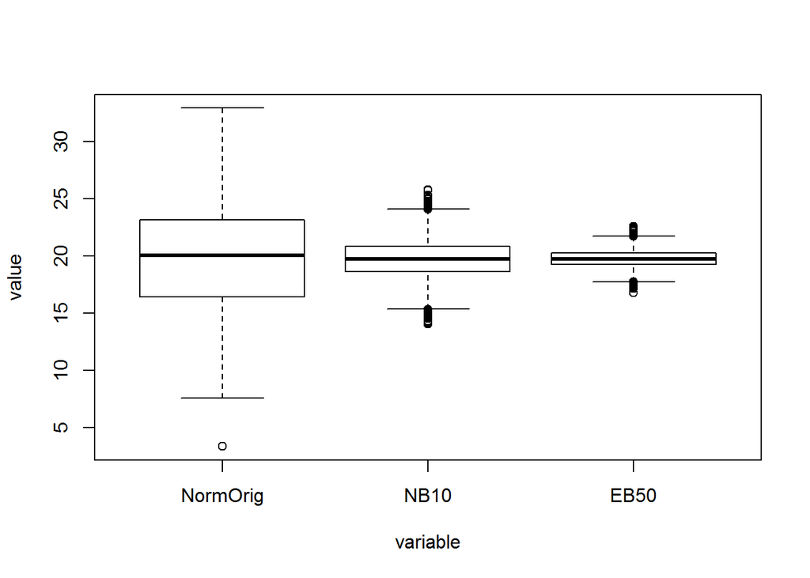

```r
plot(value ~ variable, data=NormLong)
```

## From the comparison Boxplots for the NORMAL distribution; you can see a very normal distribution in the original sample. With a Bootstrap of 10 samples then a Bootstrap of 50 samples we show that based on the Central Limit Theorem the more samples you take the less variance and closer you will get to the true Mean.

## ————————————————————

## Plot 3 samples to demonstrate the Central Limit Theorem (Exponential Ditribution)

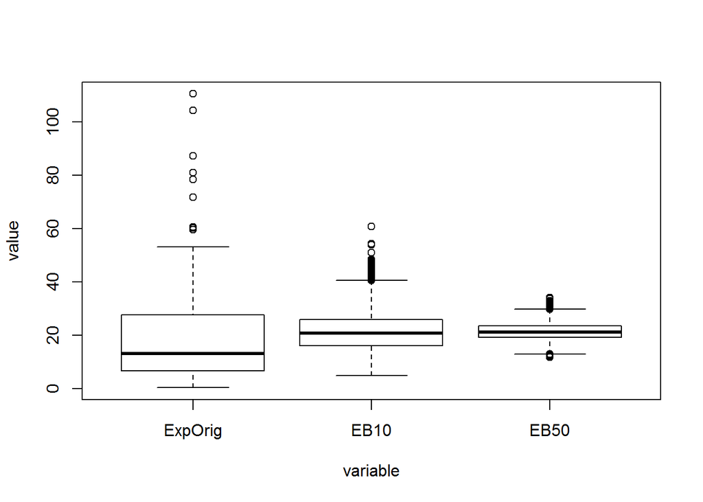

```r
plot(value ~ variable, data=ExpLong)
```

## From the comparison Boxplots for the EXPONENTIAL distribution; you can see a very right skewed distribution in the original sample. With a Bootstrap of 10 samples then a Bootstrap of 50 samples we show that based on the Central Limit Theorem the more samples you take the less variance and closer you will get to the true Mean. In the case of the exponential distribution the more samples get you closer to a normal distribution.

## ————————————————————